# Vignette - DipserseR

In this vignette you will see how to use the `disperseR` package. We will walk you through an example step by step. We will be using functions that will automatically download the needed data for you to be able to run a complete analysis for the United States. We also provide other vignettes that show you how we processed the data and how to load datasets one by one (optional).

## The step up

We start by importing the packages that we will use in the analysis. Make sure you have them installed. The functions in `disperseR` are based on the `data.table` package for faster computation, but this vignette contains many functions from the `tidyverse` family to illustrate another syntax. First, install a slightly modified version of `SplitR`.

```r
devtools::install_github( 'lhenneman/SplitR')
```

```r
library(disperseR) # our package
library(ncdf4)
library(data.table)
library(tidyverse)
library(parallel)
library(sf)
library(viridis)
library(ggplot2)
library(scales)
library(ggsn)
library(gridExtra)
library(ggmap)
library(ggrepel)
library(fst)
library(USAboundaries)
```

Next, we will use the `create_dirs()` function that creates a project folder with all the necessary sub folders. We recommend that you begin by setting up your project with this function. Provide the path to where you would like your project to live in the `location` argument. By default, if you do not specify the path, this function will create a main directory on your desktop. It will also assign paths to string variables in your environment.

This will set up is the following folders and paths to them :

- `main`: the main folder where the project will be located.
  - `input`: the input that we need for calculations.
    - `zcta_500k`: ZCTA (A Zip Code Tabulation Area) shape files
    - `hpbl`: monthly global planetary boundary layer files.
    - `meteo`: (reanalysis) meteorology files
  - `output`
    - `hysplit`: disperseR output (one file for each emissions event)
    - `ziplink`: files containing ZIP code linkages
    - `rdata`: RData files containing HyADS source-receptor matrices
    - `exp`: exposure per zipcode data
    - `graph`: graphs saved here as pdf when running functions
  - `process`: temporary files that are created when the model is running and then deleted

Note that not specifying the `location` argument will lead to a default Desktop location for the project folder. You can specify another folder by typing: `disperseR::create_dirs(location="/Users/username/projectlocation")` instead.

You should run this command before each disperseR session because the function defines global environment variables pointing to these directories. Don’t worry, your previous data will not be overwritten.

```r
disperseR::create_dirs()
```

```
#> Creating project setup
#> Project created in :  ~/Desktop
```

## The inputs

The next step is to get the data necessary for the analysis. Let’s start by loading data sets that are provided inside the `disperseR` package.

### Get the data with the `get_data()` function.

You can get most of the data required for the analysis by using the following function. This function will download the data necessary and for the data that is already attached with the package it will automatically assign it to variables in your R environment. If you want to load the data step by step check our vignette [here](https://htmlpreview.github.io/?https://github.com/garbulinskamaja/disperseR/blob/master/vignettesHTML/Vignette_Get_Data_One_by_One.html). It also contains more information about the data and their sources.

The arguments `start.year`, `start.month`,`end.year`, and `end.month` are necessary to download the meteorology reanalysis files. They will be downloaded if they are not already in the `meteo_dir` folder. The reanalysis met files are about 120 MB each.

```r
disperseR::get_data(data = "all",
  start.year = "2005",
  start.month = "11",
  end.year = "2006",
  end.month = "02")
```

```
#> Reading in the crosswalk data from disperseR
#>    Assigned to crosswalk variable
#> Reading in the PP.units.monthly1995_2017 data from disperseR
#>    Assigned to PP.units.monthly1995_2017 variable
#> Reading in the zipcodecoordinate data from disperseR
#>    Assigned to zipcodecoordinate variable
#> Start getting the ZCTA file
#>           This might take a bit, but sometimes the url will fail to connect, in this case you might want to try again later
#>    Starting Preprocessing
#>    Preprocessing complete
#>    Assigned to zcta variable
#> Start getting the planetary layers data
#>           This might take a bit, but sometimes the url will fail to connect, in this case you might want to try again later
#>    Preprocessing complete
#>    Assigned to  pblheight variable
#> Start getting the metfiles data
#> RP200511.gblRP200512.gblRP200601.gblRP200602.gbl
#> Start getting the ZCTA dataset for graphs
#>    Starting Preprocessing
#>    Preprocessing complete
#>    Assigned to zcta_dataset variable
```

### The units data

The units data should be loaded separately so that you are able to select which units to process.

This package contains annual emissions and stack height data from [EPA’s Air Markets Program Data](https://ampd.epa.gov/ampd/) and the [Energy Information Agency](https://www.eia.gov/electricity/data/eia860/) for years 2003-2012. Again, if you would like to know how these data were prepared please see the special vignette that we have attached to this package. Access it [here](https://htmlpreview.github.io/?https://github.com/garbulinskamaja/disperseR/blob/master/vignettesHTML/Vignette_Units_Preparation.html)

You can visualize the data like this in RStudio:

```r
View(disperseR::units)
```

```r
unitsrun2005 <- disperseR::units %>%
  dplyr::filter(year == 2005) %>% # only get data for 2005
  dplyr::top_n(2, SOx)  # sort and take the two rows with the biggest value for SOx

unitsrun2006 <- disperseR::units %>%
  dplyr::filter(year == 2006) %>%  # only get data for 2006
  dplyr::top_n(2, SOx)  # sort and take the two rows with the biggest value for SOx

head(unitsrun2005)
```

```
#>        ID Latitude Longitude      SOx      CO2      NOx   Height inputed year    uID
#> 1: 3136-1  40.6604  -79.3411 183555.8 13322458 13787.34 171.6024       0 2005 3136.1
#> 2: 3149-1  41.0714  -76.6672 240250.9 18188647 22388.27 213.3600       0 2005 3149.1
```

```r
# append together and transform to data table
unitsrun<-data.table::data.table(rbind(unitsrun2005, unitsrun2006))
```

## Analysis

### Define time periods to be run

HYSPLIT, as applied here, tracks air parcels emitted at certain times and locations. `disperseR` refers to these as *emissions events*. Once HYSPLIT has been run for each emissions event, the simulated parcel locations are aggregated by source, time, and location. The functions below are written to enable runs of many emissions events.

The result of running this function is a `data.table` that you can see below.

```r
input_refs <- disperseR::define_inputs(units = unitsrun,
  startday = '2005-11-01',
  endday = '2006-02-28',
  start.hours =  c(0, 6, 12, 18),
  duration = 120)

head(input_refs)
```

```
#>        ID year start_hour  start_day duration_emiss_hours duration_run_hours Latitude
#> 1: 3136-1 2005          0 2005-11-01                    1                120  40.6604
#> 2: 3136-1 2005          6 2005-11-01                    1                120  40.6604
#> 3: 3136-1 2005         12 2005-11-01                    1                120  40.6604
#> 4: 3136-1 2005         18 2005-11-01                    1                120  40.6604
#> 5: 3136-1 2005          0 2005-11-02                    1                120  40.6604
#> 6: 3136-1 2005          6 2005-11-02                    1                120  40.6604
#>    Longitude      SOx      CO2      NOx   Height inputed    uID
#> 1:  -79.3411 183555.8 13322458 13787.34 171.6024       0 3136.1
#> 2:  -79.3411 183555.8 13322458 13787.34 171.6024       0 3136.1
#> 3:  -79.3411 183555.8 13322458 13787.34 171.6024       0 3136.1
#> 4:  -79.3411 183555.8 13322458 13787.34 171.6024       0 3136.1
#> 5:  -79.3411 183555.8 13322458 13787.34 171.6024       0 3136.1
#> 6:  -79.3411 183555.8 13322458 13787.34 171.6024       0 3136.1
```

### Run HYSPLIT

The following examples show how to run a small subset (chosen to provide workable examples on a laptop) of emissions events, link to spatial domains—U.S. ZIP codes, U.S. counties, or a regular grid—and plot the results.

The `run_disperser_parallel()` function runs HYSPLIT for each emissions event. Inputs defined above, including the projected ZCTA shape file (`zcta`), the ZIP-ZCTA crosswalk (`crosswalk`), the planetary boundary layer raster (`pblheight`), are necessary in the function call.

**If you get an error running HYSPLIT, it is likely because the meteorology files did not download correctly. Check your `meteo_dir` to ensure all files are present and at least 100MB in size.**

Below we subset the data to run the process on a local computer. We only choose the first day and first hour of each month for each of the units that we chose. You can choose the events you are interested in.

```r
input_refs_subset <- input_refs[format(as.Date(input_refs$start_day,
  format = "%Y-%m-%d"),
  format = "%d") == "01" & start_hour == 0]
```

`input.refs` should be the data table that is the result of the `define_input()` function. Remember that here we are running the model just on a subset so we will set `input.refs = input_refs_subset`

The `pbl.height` argument is `NULL` by default but you should provide it for the function to run properly. We use the `pblheight` data.

The package has the possibility to use two types of species. The default one is `species = 'so2'`, but you can also use particulate sulfate `species = 'so4p'`.

The `parallel::detectCores()` function automatically detects the number of cores on your machine. If you would like to change on how many cores the model should be run please specify the number of cores. Here, for example we specified the number of cores to be the number of the cores on the machine. If you would like to run this model sequentially please set `mc.cores = 1`.

It is possible that running the below code with output a warning “WARNING: map background file not found ../graphics/arlmap”. It is safe to ignore it.

```r
hysp_raw <- disperseR::run_disperser_parallel(input.refs = input_refs_subset,
   pbl.height = pblheight,
   species = 'so2',
   proc_dir = proc_dir,
   overwrite = FALSE, ## FALSE BY DEFAULT
   npart = 100,
   keep.hysplit.files = FALSE, ## FALSE BY DEFAULT
   mc.cores = parallel::detectCores())
```

```
#> Warning in parallel::mclapply(X = run_sample, FUN = run_fac, input.refs = input.refs, :
#> scheduled core 7 encountered error in user code, all values of the job will be affected
```

### Link results to spatial domains

Most current implementations of HyADS, instead of linking dispersion patterns from individual emissions events, link the patterns by month. With the `link_all_units()` function, users can link all air parcels to three spatial domains—U.S. ZIP codes, U.S. counties, or a regular grid—by month for specified units. Here, we define the variables `yearmons` with combinations of years and months. `link_all_units()` uses the support functions `disperser_link_zips()`, `disperser_link_counties()`, `disperser_link_grids()` to read in raw HYSPLIT output files produced by the `run_disperser_parallel()` and links the corresponding parcel locations to the appropriate spatial domain. The user selects the spatial domain through the `link.to` argument—it can be set to one of “zips”, “counties”, or “grids”.

`link_all_units()` can be set to paralelize the runs by splitting different months on different cores, but you can make it serial just by setting the `mc.cores = 1`. The result of `link_all_units()` is a data.table of ZIP codes, counties, or grids and relative contributions `N`, and an identical `.csv` file is saved to the folder with a path specified by the `ziplink_dir` variable. `N` is not weighted by the `unit`’s emissions.

Below we present how to use `link_all_units()` for chosen units. First, we create an argument (called `yearmons` here) denoting the year and month combinations for which we would like to calculate unweighted exposure. Here we only choose July 2005 through June 2006 to cover all of the example runs specified above, and we create the variable using the `get_yearmon()` function.

```r
yearmons <- disperseR::get_yearmon(start.year = "2005",
  start.month = "07",
  end.year = "2006",
  end.month = "06")
```

Let’s look again at our `unitsrun` data set.

```r
unitsrun
```

```
#>        ID Latitude Longitude       SOx      CO2       NOx   Height inputed year    uID
#> 1: 3136-1  40.6604  -79.3411 183555.84 13322458 13787.340 171.6024       0 2005 3136.1
#> 2: 3149-1  41.0714  -76.6672 240250.87 18188647 22388.272 213.3600       0 2005 3149.1
#> 3: 3136-1  40.6604  -79.3411  77544.22  5789319  5434.327 171.6024       0 2006 3136.1
#> 4: 3136-2  40.6604  -79.3411  86809.31  6481797  7349.269 171.6024       0 2006 3136.2
```

We only have three units in our `unitsrun` data set. “3136-1”, “3136-2” and “3149-1”. We will run `link_all_units()` for all of them (it is possible to pass `link_all_units()` a single unit if desired). The function will return only the values for units and months that could have been linked to one another.

If you want to run the function for a specific start and end date you can specify the `start.date` and the `end.date` arguments. For example, `start.date="2005-01-02"` for 2 January 2005. These arguments are set to `NULL` by default and the function computes the start and the end dates using the `year.mons` provided.

`pbl.height = pblheight` by default but you can change it. The same applies to `crosswalk. = crosswalk` (`crosswalk.` is only required for linking to ZIP codes). `counties.` is required for linking to counties, and is set as `counties. = USAboundaries::us_counties( )` by default. If you’d only like to save time and only link to ZIP codes or counties in a subset of the country, provide `crosswalk.` or `counties.` that correspond to the domain of interest.

Changing `duration.run.hours` to values less than that applied in `run_disperser_parallel()` allows the exploration of air parcel locations in closer time proximity to each emissions event.

`res.link` sets the grid resolution in meters (default is 12000 or 12km). Since parcel locations are first assigned to a grid before further spatial allocation, this setting has the potential to impact all results. A higher `res.link` with `link.to = "grids"` will result in faster run time and smaller output files.

```r
linked_zips <- disperseR::link_all_units(
  units.run = unitsrun,
  link.to = 'zips',
  mc.cores = parallel::detectCores(),
  year.mons = yearmons,
  pbl.height = pblheight,
  crosswalk. = crosswalk,
  duration.run.hours = 20,
  res.link = 12000,
  overwrite = FALSE)
```

```
#> processed unit 3136-1
#> processed unit 3149-1
#> processed unit 3136-2
```

```r
# link all units to counties
linked_counties <- disperseR::link_all_units(
  units.run=unitsrun,
  link.to = 'counties',
  mc.cores = parallel::detectCores(),
  year.mons = yearmons,
  pbl.height = pblheight,
  counties. = USAboundaries::us_counties( ),
  crosswalk. = NULL,
  duration.run.hours = 20,
  overwrite = FALSE)
```

```
#> processed unit 3136-1
#> processed unit 3149-1
#> processed unit 3136-2
```

```r
# link all units to grids
linked_grids <- disperseR::link_all_units(
  units.run=unitsrun,
  link.to = 'grids',
  mc.cores = parallel::detectCores(),
  year.mons = yearmons,
  pbl.height = pblheight,
  crosswalk. = NULL,
  duration.run.hours = 20,
  overwrite = FALSE)
```

```
#> processed unit 3136-1
#> processed unit 3149-1
#> processed unit 3136-2
```

```r
head(linked_zips)
```

```
#>      ZIP N  month     ID                         comb
#> 1: 03579 1 200511 3136-1 month: 200511 unitID :3136-1
#> 2: 04408 1 200511 3136-1 month: 200511 unitID :3136-1
#> 3: 04414 1 200511 3136-1 month: 200511 unitID :3136-1
#> 4: 04416 1 200511 3136-1 month: 200511 unitID :3136-1
#> 5: 04417 1 200511 3136-1 month: 200511 unitID :3136-1
#> 6: 04418 1 200511 3136-1 month: 200511 unitID :3136-1
```

```r
head(linked_counties)
```

```
#>    statefp countyfp   state_name       name geoid  N  month     ID
#> 1:      39      131         Ohio       Pike 39131 NA 200511 3136-1
#> 2:      46      003 South Dakota     Aurora 46003 NA 200511 3136-1
#> 3:      55      035    Wisconsin Eau Claire 55035 NA 200511 3136-1
#> 4:      72      145  Puerto Rico  Vega Baja 72145 NA 200511 3136-1
#> 5:      48      259        Texas    Kendall 48259 NA 200511 3136-1
#> 6:      40      015     Oklahoma      Caddo 40015 NA 200511 3136-1
#>                            comb
#> 1: month: 200511 unitID :3136-1
#> 2: month: 200511 unitID :3136-1
#> 3: month: 200511 unitID :3136-1
#> 4: month: 200511 unitID :3136-1
#> 5: month: 200511 unitID :3136-1
#> 6: month: 200511 unitID :3136-1
```

```r
head(linked_grids)
```

```
#>          x       y N  month     ID                         comb
#> 1: 4050000 5490000 1 200511 3136-1 month: 200511 unitID :3136-1
#> 2: 4014000 5478000 1 200511 3136-1 month: 200511 unitID :3136-1
#> 3: 4038000 5478000 1 200511 3136-1 month: 200511 unitID :3136-1
#> 4: 3978000 5262000 1 200511 3136-1 month: 200511 unitID :3136-1
#> 5: 3978000 5250000 1 200511 3136-1 month: 200511 unitID :3136-1
#> 6: 3954000 5238000 1 200511 3136-1 month: 200511 unitID :3136-1
```

It could be the case that data could not have been linked for a specific month and unit. Below we show how to take a look at the combinations of units and months that were successfully linked. We can easily do it in the following way:

```r
unique(linked_zips$comb)
```

```
#> [1] "month: 200511 unitID :3136-1" "month: 200512 unitID :3136-1"
#> [3] "month: 20061 unitID :3136-1"  "month: 20062 unitID :3136-1"
#> [5] "month: 200512 unitID :3149-1" "month: 20061 unitID :3136-2"
#> [7] "month: 20062 unitID :3136-2"
```

### Visualization of the results.

At this point, it makes sense to take a look at the results to see which ZIP codes are impacted by emissions from the facility whose impacts we modeled above. We can see how the impact looks by looking at numbers and plots. We will first just look at the numbers. For this purpose, we created a function `create_impact_table_single()` that generates a specific data.table.

And now we can use the `create_impact_table_single()` function to see the computed impact for a single month and a single unit.

Keep in mind, since we only modeled a subset of the potential model runs defined in `input_refs()`, the impacts contained in `impact_table_single` and plotted below include only results from a single emissions event. Further, the plotted values are “HyADS raw exposure”, i.e., not weighted by emissions. So, a value of 0.01 represents 10x more exposure than a value of 0.001, but only in relation to unit 3136-1.

We select the spatial link based on the `link.to` argument. The function returns data.tables that include an `sf` geometry column for easy plotting.

```r
impact_table_zip_single <- disperseR::create_impact_table_single(
  data.linked=linked_zips,
  link.to = 'zips',
  data.units = unitsrun,
  zcta.dataset = zcta_dataset,
  map.unitID = "3136-1",
  map.month = "200511",
  metric = 'N')
impact_table_county_single <- disperseR::create_impact_table_single(
  data.linked=linked_counties,
  link.to = 'counties',
  data.units = unitsrun,
  counties. = USAboundaries::us_counties( ),
  map.unitID = "3136-1",
  map.month = "200511",
  metric = 'N')
impact_table_grid_single <- disperseR::create_impact_table_single(
  data.linked=linked_grids,
  link.to = 'grids',
  data.units = unitsrun,
  map.unitID = "3136-1",
  map.month = "200511",
  metric = 'N')

head(impact_table_zip_single)
```

```
#>        ID  month Latitude Longitude metric   ZIP  ZCTA       CITY STATE TOTALESTIMATE
#> 1: 3136-1 200511  40.6604  -79.3411      1 03579 03579      Errol    NH           355
#> 2: 3136-1 200511  40.6604  -79.3411      1 04408 04408     Aurora    ME           172
#> 3: 3136-1 200511  40.6604  -79.3411      1 04414 04414 Brownville    ME          1209
#> 4: 3136-1 200511  40.6604  -79.3411      1 04416 04416  Bucksport    ME          5451
#> 5: 3136-1 200511  40.6604  -79.3411      1 04417 04417 Burlington    ME           233
#> 6: 3136-1 200511  40.6604  -79.3411      1 04418 04418  Greenbush    ME          1544
#>    MARGINOFERROR geometry
#> 1:            54  <XY[1]>
#> 2:            55  <XY[5]>
#> 3:           166  <XY[1]>
#> 4:           111  <XY[1]>
#> 5:            52  <XY[1]>
#> 6:           145  <XY[1]>
```

In a similar way we can just plot the results using the `plot_impact_single()` function. A customized title can be set using the `plot.name` argument. Additional inputs can be passed to ggplot2’s `theme` function to customize your plot.

`zoom = T` by default and is authomatically adjusted depending on the plot values. You can set `zoom = F` to display the map of the whole country. Note that the linked grids extend beyond the US boarders because any grid across the world may be impacted by the given facilities.

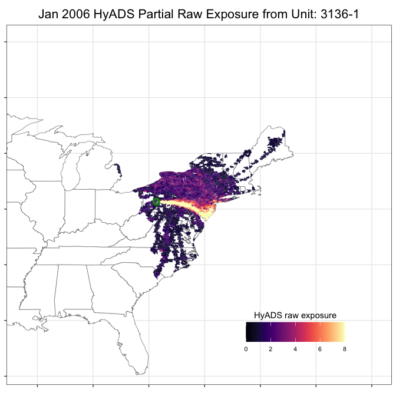

```r
link_plot_zips <- disperseR::plot_impact_single(
  data.linked = linked_zips,
  link.to = 'zips',
  map.unitID = "3136-1",
  map.month = "20061",
  data.units = unitsrun,
  zcta.dataset = zcta_dataset,
  metric = 'N',
  graph.dir = graph_dir,
  zoom = T, # TRUE by default
  legend.name = 'HyADS raw exposure',
  # other parameters passed to ggplot2::theme()
  axis.text = element_blank(),
  legend.position = c( .75, .15))
link_plot_grids <- disperseR::plot_impact_single(
  data.linked = linked_grids,
  link.to = 'grids',
  map.unitID = "3136-1",
  map.month = "20061",
  data.units = unitsrun,
  metric = 'N',
  graph.dir = graph_dir,
  zoom = F, # TRUE by default
  legend.name = 'HyADS raw exposure',
  # other parameters passed to ggplot2::theme()
  axis.text = element_blank(),
  legend.position = c( .75, .15))
link_plot_counties <- disperseR::plot_impact_single(
  data.linked = linked_counties,
  link.to = 'counties',
  map.unitID = "3136-1",
  map.month = "20061",
  counties. = USAboundaries::us_counties( ),
  data.units = unitsrun,
  metric = 'N',
  graph.dir = graph_dir,
  zoom = T, # TRUE by default
  legend.name = 'HyADS raw exposure',
  # other parameters passed to ggplot2::theme()
  axis.text = element_blank(),
  legend.position = c( .75, .15))

link_plot_zips
```

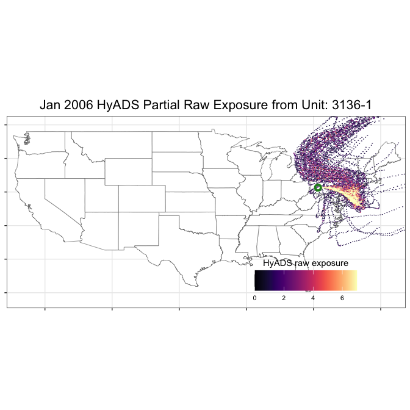

```r
link_plot_grids
```

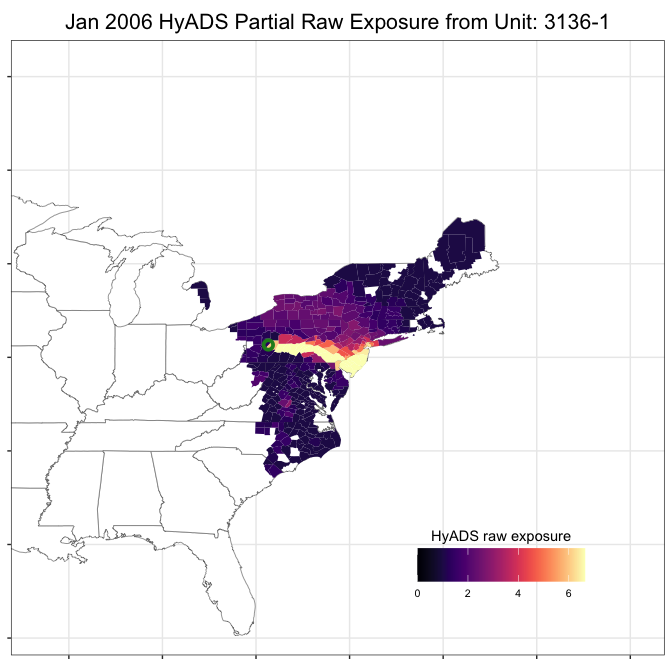

```r
link_plot_counties
```

### Combine all results into RData file.

So far, we have run two worker functions important to the implementation of HyADS:

- `run_disperser_parallel()` ran HYSPLIT for unit-date-time emission event combinations and saved an output file for each gathered output files from `run_disperser_parallel()`.
- `link_all_units()` function grouped them by month and unit, and linked the HYSPLIT parcel locations contained in the files to various three different scales.

In practice, these two worker functions may need to be implemented in parallel R sessions on a cluster to improve efficiency. It helps for future analyses to gather the relevant monthly files and save them as a single RData file. This is made possible by `combine_monthly_links()`, which saves an RData file of annual monthly results to the `rda_dir`. Names of the resulting objects give the year-month combinations in each object.

```r
combined_ziplinks <- disperseR::combine_monthly_links(
  month_YYYYMMs = yearmons,
  link.to = 'zips',
  filename = 'hyads_vig_unwgted_zips.RData')
```

```
#> [1] "No data files for month_YYYYMMs 20057"
#> [1] "No data files for month_YYYYMMs 20058"
#> [1] "No data files for month_YYYYMMs 20059"
#> [1] "No data files for month_YYYYMMs 200510"
#> [1] "Reading and merging month 11 in year 2005"
#> [1] "Reading and merging month 12 in year 2005"
#> [1] "Reading and merging month 01 in year 2006"
#> [1] "Reading and merging month 02 in year 2006"
#> [1] "No data files for month_YYYYMMs 20063"
#> [1] "No data files for month_YYYYMMs 20064"
#> [1] "No data files for month_YYYYMMs 20065"
#> [1] "No data files for month_YYYYMMs 20066"
#> [1] "Monthly RData file written to ~/Desktop/main/output/rdata/hyads_vig_unwgted_zips.RData"
```

```r
combined_countylinks <- disperseR::combine_monthly_links(
  month_YYYYMMs = yearmons,
  link.to = 'counties',
  filename = 'hyads_vig_unwgted_counties.RData')
```

```
#> [1] "No data files for month_YYYYMMs 20057"
#> [1] "No data files for month_YYYYMMs 20058"
#> [1] "No data files for month_YYYYMMs 20059"
#> [1] "No data files for month_YYYYMMs 200510"
#> [1] "Reading and merging month 11 in year 2005"
#> [1] "Reading and merging month 12 in year 2005"
#> [1] "Reading and merging month 01 in year 2006"
#> [1] "Reading and merging month 02 in year 2006"
#> [1] "No data files for month_YYYYMMs 20063"
#> [1] "No data files for month_YYYYMMs 20064"
#> [1] "No data files for month_YYYYMMs 20065"
#> [1] "No data files for month_YYYYMMs 20066"
#> [1] "Monthly RData file written to ~/Desktop/main/output/rdata/hyads_vig_unwgted_counties.RData"
```

```r
combined_gridlinks <- disperseR::combine_monthly_links(
  month_YYYYMMs = yearmons,
  link.to = 'grids',
  filename = 'hyads_vig_unwgted_grids.RData')
```

```
#> [1] "No data files for month_YYYYMMs 20057"
#> [1] "No data files for month_YYYYMMs 20058"
#> [1] "No data files for month_YYYYMMs 20059"
#> [1] "No data files for month_YYYYMMs 200510"
#> [1] "Reading and merging month 11 in year 2005"
#> [1] "Reading and merging month 12 in year 2005"
#> [1] "Reading and merging month 01 in year 2006"
#> [1] "Reading and merging month 02 in year 2006"
#> [1] "No data files for month_YYYYMMs 20063"
#> [1] "No data files for month_YYYYMMs 20064"
#> [1] "No data files for month_YYYYMMs 20065"
#> [1] "No data files for month_YYYYMMs 20066"
#> [1] "Monthly RData file written to ~/Desktop/main/output/rdata/hyads_vig_unwgted_grids.RData"
```

```r
names(combined_ziplinks)
```

```
#> [1] "MAP11.2005" "MAP12.2005" "MAP1.2006"  "MAP2.2006"
```

## Calculate and extract useful information from the results

Up until now, this vignette has focused on producing unweighted HyADS results. Once the procedure above has been followed, it is fairly straightforward to weight the unweighted HyADS results by emissions (or other quantity) and aggregate the results by source, receptor, and/or time period.

### Weight the results by emissions

The `create_impact_table_weighted()` function takes as input the .RData file created by `combine_monthly_links()` and monthly power plant emissions. The user can select the disperseR year (`year.D`), the emissions year (`year.E`), the weighting pollutant (although it does not necessarily have to be a pollutant), the source aggregation (you can choose `source.agg = "total"`, `source.agg = "facility"`, or `source.agg = "unit"`), the time aggregation (`time.agg = "month"` or `time.agg = "year"`).

Here, we first calculate the annual HyADS emissions weighted exposure for all emissions modeled above and plot the results. The plots require a large amount of working memory, and may require you to clear your image history (if using RStudio).

```r
exp_ann_unit_zip <- disperseR::calculate_exposure(
  year.E = 2005,
  year.D = 2005,
  link.to = 'zips',
  pollutant = 'SO2.tons',
  rda_file = file.path(rdata_dir, "hyads_vig_unwgted_zips.RData"),
  exp_dir = exp_dir,
  units.mo = PP.units.monthly1995_2017,
  source.agg = 'unit',
  time.agg = 'month',
  return.monthly.data = T)
```

```
#> Calculating zips exposures for HYSPLIT year 2005 and emissions year 2005!
#>    MAP1.2005 not loaded in environment. If you want it linked, either load RData file before or specify rda_file
#>    MAP2.2005 not loaded in environment. If you want it linked, either load RData file before or specify rda_file
#>    MAP3.2005 not loaded in environment. If you want it linked, either load RData file before or specify rda_file
#>    MAP4.2005 not loaded in environment. If you want it linked, either load RData file before or specify rda_file
#>    MAP5.2005 not loaded in environment. If you want it linked, either load RData file before or specify rda_file
#>    MAP6.2005 not loaded in environment. If you want it linked, either load RData file before or specify rda_file
#>    MAP7.2005 not loaded in environment. If you want it linked, either load RData file before or specify rda_file
#>    MAP8.2005 not loaded in environment. If you want it linked, either load RData file before or specify rda_file
#>    MAP9.2005 not loaded in environment. If you want it linked, either load RData file before or specify rda_file
#>    MAP10.2005 not loaded in environment. If you want it linked, either load RData file before or specify rda_file
```

```r
exp_ann_unit_grids <- disperseR::calculate_exposure(
  year.E = 2005,
  year.D = 2005,
  link.to = 'grids',
  pollutant = 'SO2.tons',
  rda_file = file.path(rdata_dir, "hyads_vig_unwgted_grids.RData"),
  exp_dir = exp_dir,
  units.mo = PP.units.monthly1995_2017,
  source.agg = 'unit',
  time.agg = 'month',
  return.monthly.data = T)
```

```
#> Calculating grids exposures for HYSPLIT year 2005 and emissions year 2005!
#>    MAP1.2005 not loaded in environment. If you want it linked, either load RData file before or specify rda_file
#>    MAP2.2005 not loaded in environment. If you want it linked, either load RData file before or specify rda_file
#>    MAP3.2005 not loaded in environment. If you want it linked, either load RData file before or specify rda_file
#>    MAP4.2005 not loaded in environment. If you want it linked, either load RData file before or specify rda_file
#>    MAP5.2005 not loaded in environment. If you want it linked, either load RData file before or specify rda_file
#>    MAP6.2005 not loaded in environment. If you want it linked, either load RData file before or specify rda_file
#>    MAP7.2005 not loaded in environment. If you want it linked, either load RData file before or specify rda_file
#>    MAP8.2005 not loaded in environment. If you want it linked, either load RData file before or specify rda_file
#>    MAP9.2005 not loaded in environment. If you want it linked, either load RData file before or specify rda_file
#>    MAP10.2005 not loaded in environment. If you want it linked, either load RData file before or specify rda_file
```

```r
exp_ann_unit_counties <- disperseR::calculate_exposure(
  year.E = 2005,
  year.D = 2005,
  link.to = 'counties',
  pollutant = 'SO2.tons',
  rda_file = file.path(rdata_dir, "hyads_vig_unwgted_counties.RData"),
  exp_dir = exp_dir,
  units.mo = PP.units.monthly1995_2017,
  source.agg = 'unit',
  time.agg = 'month',
  return.monthly.data = T)
```

```
#> Calculating counties exposures for HYSPLIT year 2005 and emissions year 2005!
#>    MAP1.2005 not loaded in environment. If you want it linked, either load RData file before or specify rda_file
#>    MAP2.2005 not loaded in environment. If you want it linked, either load RData file before or specify rda_file
#>    MAP3.2005 not loaded in environment. If you want it linked, either load RData file before or specify rda_file
#>    MAP4.2005 not loaded in environment. If you want it linked, either load RData file before or specify rda_file
#>    MAP5.2005 not loaded in environment. If you want it linked, either load RData file before or specify rda_file
#>    MAP6.2005 not loaded in environment. If you want it linked, either load RData file before or specify rda_file
#>    MAP7.2005 not loaded in environment. If you want it linked, either load RData file before or specify rda_file
#>    MAP8.2005 not loaded in environment. If you want it linked, either load RData file before or specify rda_file
#>    MAP9.2005 not loaded in environment. If you want it linked, either load RData file before or specify rda_file
#>    MAP10.2005 not loaded in environment. If you want it linked, either load RData file before or specify rda_file
```

We can plot the results as following using the `plot_impact_weighted()` function. Again, a customized title can be set using the `plot.name` argument, and addional arguments can be passed to ggplot2’s `theme` function to customize.

Same as before, `zoom = T` by default and is authomatically adjusted depending on the plot values. You can set `zoom = F` to display the map of the whole country.

Please note that the produced graph will be automatically saved in the folder specified in the `graph.dir` argument. Here we set `graph.dir = graph_dir`. `graph_dir` should have been automatically created by the `create_dirs()` function.

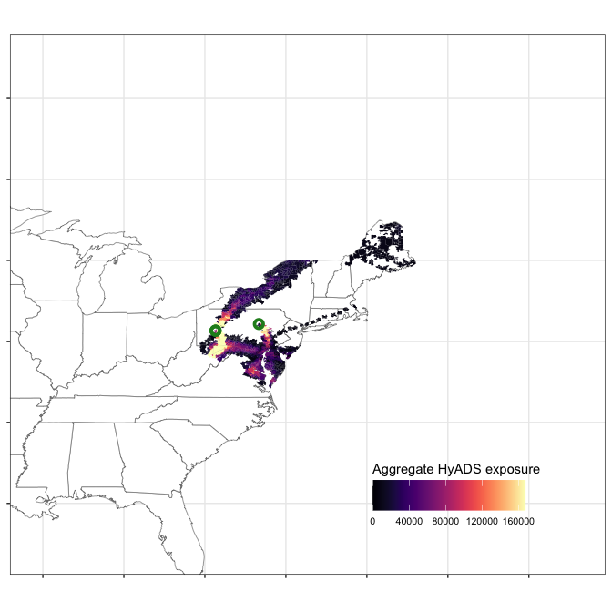

```r
zip_exp_ann_plot <- disperseR::plot_impact_weighted(
  data.linked = exp_ann_unit_zip,
  data.units = unitsrun,
  link.to = 'zips',
  zcta.dataset = zcta_dataset,
  time.agg = 'year',
  metric = 'hyads',
  legend.name = 'Aggregate HyADS exposure',
  zoom = T, # TRUE by default
  graph.dir = graph_dir,
  map.month = NULL, # NULL by default change if time.agg = 'month'
  # other parameters passed to ggplot2::theme()
  axis.text = element_blank(),
  legend.position = c( .75, .15)) # 0 by default

counties_exp_ann_plot <- disperseR::plot_impact_weighted(
  data.linked = exp_ann_unit_counties,
  data.units = unitsrun,
  link.to = 'counties',
  counties. = USAboundaries::us_counties( ),
  time.agg = 'year',
  metric = 'hyads',
  legend.name = 'Aggregate HyADS exposure',
  zoom = T, # TRUE by default
  graph.dir = graph_dir,
  map.month = NULL, # NULL by default change if time.agg = 'month'
  # other parameters passed to ggplot2::theme()
  axis.text = element_blank(),
  legend.position = c( .75, .15)) # 0 by default

grids_exp_ann_plot <- disperseR::plot_impact_weighted(
  data.linked = exp_ann_unit_grids,
  data.units = unitsrun,
  link.to = 'grids',
  time.agg = 'year',
  metric = 'hyads',
  legend.name = 'Aggregate HyADS exposure',
  zoom = T, # TRUE by default
  graph.dir = graph_dir,
  map.month = NULL, # NULL by default change if time.agg = 'month'
  # other parameters passed to ggplot2::theme()
  axis.text = element_blank(),
  legend.position = c( .75, .15)) # 0 by default

zip_exp_ann_plot
```

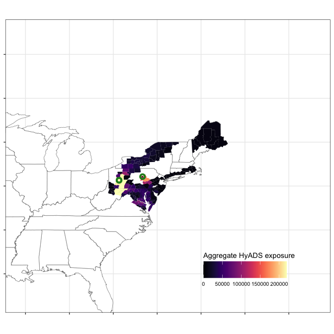

```r
counties_exp_ann_plot
```

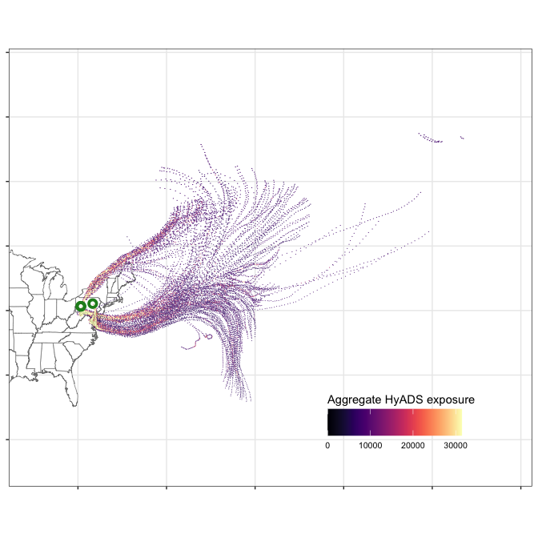

```r
grids_exp_ann_plot
```

Let’s now see how to plot a monthly exposure.

Results are saved to the `exp_dir` and returned, but `return.monthly.data` must be set to true to return data when `time.agg = 'month'` (the default was set to save working memory space).

**It is very important to provide a month for which we have available data**

```r
exp_mon_unit_zip <- disperseR::calculate_exposure(
  year.E = 2005,
  year.D = 2005,
  link.to = 'zips',
  pollutant = 'SO2.tons',
  rda_file = file.path(rdata_dir, "hyads_vig_unwgted_zips.RData"),
  exp_dir = exp_dir,
  units.mo = PP.units.monthly1995_2017,
  source.agg = 'unit',
  time.agg = 'month',
  return.monthly.data = T)
```

```
#> Calculating zips exposures for HYSPLIT year 2005 and emissions year 2005!
#>    MAP1.2005 not loaded in environment. If you want it linked, either load RData file before or specify rda_file
#>    MAP2.2005 not loaded in environment. If you want it linked, either load RData file before or specify rda_file
#>    MAP3.2005 not loaded in environment. If you want it linked, either load RData file before or specify rda_file
#>    MAP4.2005 not loaded in environment. If you want it linked, either load RData file before or specify rda_file
#>    MAP5.2005 not loaded in environment. If you want it linked, either load RData file before or specify rda_file
#>    MAP6.2005 not loaded in environment. If you want it linked, either load RData file before or specify rda_file
#>    MAP7.2005 not loaded in environment. If you want it linked, either load RData file before or specify rda_file
#>    MAP8.2005 not loaded in environment. If you want it linked, either load RData file before or specify rda_file
#>    MAP9.2005 not loaded in environment. If you want it linked, either load RData file before or specify rda_file
#>    MAP10.2005 not loaded in environment. If you want it linked, either load RData file before or specify rda_file
```

```r
exp_mon_unit_grids <- disperseR::calculate_exposure(
  year.E = 2005,
  year.D = 2005,
  link.to = 'grids',
  pollutant = 'SO2.tons',
  rda_file = file.path(rdata_dir, "hyads_vig_unwgted_grids.RData"),
  exp_dir = exp_dir,
  units.mo = PP.units.monthly1995_2017,
  source.agg = 'unit',
  time.agg = 'month',
  return.monthly.data = T)
```

```
#> Calculating grids exposures for HYSPLIT year 2005 and emissions year 2005!
#>    MAP1.2005 not loaded in environment. If you want it linked, either load RData file before or specify rda_file
#>    MAP2.2005 not loaded in environment. If you want it linked, either load RData file before or specify rda_file
#>    MAP3.2005 not loaded in environment. If you want it linked, either load RData file before or specify rda_file
#>    MAP4.2005 not loaded in environment. If you want it linked, either load RData file before or specify rda_file
#>    MAP5.2005 not loaded in environment. If you want it linked, either load RData file before or specify rda_file
#>    MAP6.2005 not loaded in environment. If you want it linked, either load RData file before or specify rda_file
#>    MAP7.2005 not loaded in environment. If you want it linked, either load RData file before or specify rda_file
#>    MAP8.2005 not loaded in environment. If you want it linked, either load RData file before or specify rda_file
#>    MAP9.2005 not loaded in environment. If you want it linked, either load RData file before or specify rda_file
#>    MAP10.2005 not loaded in environment. If you want it linked, either load RData file before or specify rda_file
```

```r
exp_mon_unit_counties <- disperseR::calculate_exposure(
  year.E = 2005,
  year.D = 2005,
  link.to = 'counties',
  pollutant = 'SO2.tons',
  rda_file = file.path(rdata_dir, "hyads_vig_unwgted_counties.RData"),
  exp_dir = exp_dir,
  units.mo = PP.units.monthly1995_2017,
  source.agg = 'unit',
  time.agg = 'month',
  return.monthly.data = T)
```

```
#> Calculating counties exposures for HYSPLIT year 2005 and emissions year 2005!
#>    MAP1.2005 not loaded in environment. If you want it linked, either load RData file before or specify rda_file
#>    MAP2.2005 not loaded in environment. If you want it linked, either load RData file before or specify rda_file
#>    MAP3.2005 not loaded in environment. If you want it linked, either load RData file before or specify rda_file
#>    MAP4.2005 not loaded in environment. If you want it linked, either load RData file before or specify rda_file
#>    MAP5.2005 not loaded in environment. If you want it linked, either load RData file before or specify rda_file
#>    MAP6.2005 not loaded in environment. If you want it linked, either load RData file before or specify rda_file
#>    MAP7.2005 not loaded in environment. If you want it linked, either load RData file before or specify rda_file
#>    MAP8.2005 not loaded in environment. If you want it linked, either load RData file before or specify rda_file
#>    MAP9.2005 not loaded in environment. If you want it linked, either load RData file before or specify rda_file
#>    MAP10.2005 not loaded in environment. If you want it linked, either load RData file before or specify rda_file
```

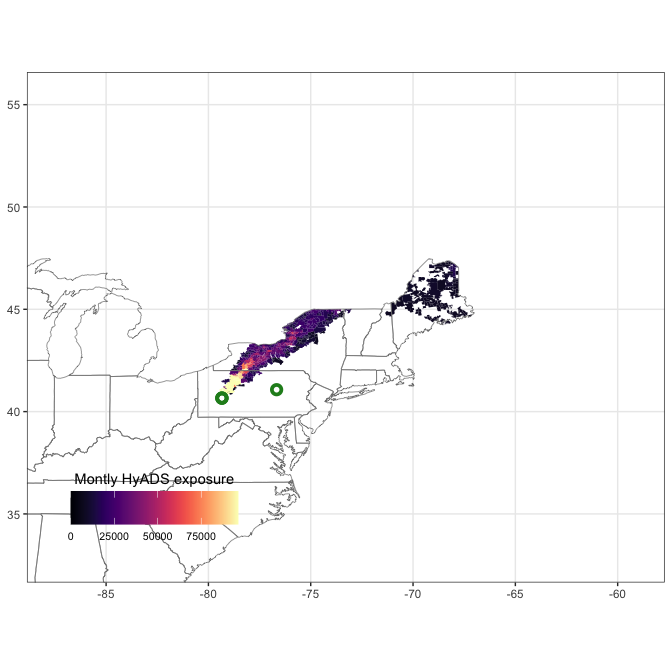

```r
zip_exp_mon_plot <- disperseR::plot_impact_weighted(
  data.linked = exp_mon_unit_zip,
  data.units = unitsrun,
  zcta.dataset = zcta_dataset,
  time.agg = 'month',
  map.month = "200511",
  metric = 'hyads',
  legend.name = 'Montly HyADS exposure',
  zoom = T, # TRUE by default
  graph.dir = graph_dir)

zip_exp_mon_plot
```

### Plot unit-specific impacts over time

```r
zip_exp_unit_mon2005 <- disperseR::calculate_exposure(
  rda_file = file.path(rdata_dir, "hyads_vig_unwgted_zips.RData"),
  units.mo = PP.units.monthly1995_2017,
  link.to = 'zips',
  year.E = 2005,
  year.D = 2005,
  pollutant = 'SO2.tons',
  source.agg = 'unit', # note!
  time.agg = 'month',
  exp_dir = exp_dir,
  return.monthly.data = T)
```

```
#> Calculating zips exposures for HYSPLIT year 2005 and emissions year 2005!
#>    MAP1.2005 not loaded in environment. If you want it linked, either load RData file before or specify rda_file
#>    MAP2.2005 not loaded in environment. If you want it linked, either load RData file before or specify rda_file
#>    MAP3.2005 not loaded in environment. If you want it linked, either load RData file before or specify rda_file
#>    MAP4.2005 not loaded in environment. If you want it linked, either load RData file before or specify rda_file
#>    MAP5.2005 not loaded in environment. If you want it linked, either load RData file before or specify rda_file
#>    MAP6.2005 not loaded in environment. If you want it linked, either load RData file before or specify rda_file
#>    MAP7.2005 not loaded in environment. If you want it linked, either load RData file before or specify rda_file
#>    MAP8.2005 not loaded in environment. If you want it linked, either load RData file before or specify rda_file
#>    MAP9.2005 not loaded in environment. If you want it linked, either load RData file before or specify rda_file
#>    MAP10.2005 not loaded in environment. If you want it linked, either load RData file before or specify rda_file
```

```r
zip_exp_unit_mon2006 <- disperseR::calculate_exposure(
  rda_file = file.path(rdata_dir, "hyads_vig_unwgted_zips.RData"),
  units.mo = PP.units.monthly1995_2017,
  link.to = 'zips',
  year.E = 2006,
  year.D = 2006,
  pollutant = 'SO2.tons',
  source.agg = 'unit', # note!
  time.agg = 'month',
  exp_dir = exp_dir,
  return.monthly.data = T)
```

```
#> Calculating zips exposures for HYSPLIT year 2006 and emissions year 2006!
#>    MAP3.2006 not loaded in environment. If you want it linked, either load RData file before or specify rda_file
#>    MAP4.2006 not loaded in environment. If you want it linked, either load RData file before or specify rda_file
#>    MAP5.2006 not loaded in environment. If you want it linked, either load RData file before or specify rda_file
#>    MAP6.2006 not loaded in environment. If you want it linked, either load RData file before or specify rda_file
#>    MAP7.2006 not loaded in environment. If you want it linked, either load RData file before or specify rda_file
#>    MAP8.2006 not loaded in environment. If you want it linked, either load RData file before or specify rda_file
#>    MAP9.2006 not loaded in environment. If you want it linked, either load RData file before or specify rda_file
#>    MAP10.2006 not loaded in environment. If you want it linked, either load RData file before or specify rda_file
#>    MAP11.2006 not loaded in environment. If you want it linked, either load RData file before or specify rda_file
#>    MAP12.2006 not loaded in environment. If you want it linked, either load RData file before or specify rda_file
```

```r
zip_exp_unit_mon <- rbind(zip_exp_unit_mon2005, zip_exp_unit_mon2006)
```

And now we can plot the results

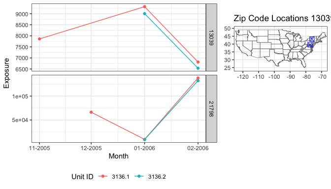

```r
zipcodes <- c("13039","21798", "03804")

zip_exp_unit <- disperseR::plot_impact_unit(
  data.linked = zip_exp_unit_mon,
  zip.codes = zipcodes,
  graph.dir = graph_dir)
```

### Rank facilities.

In the examples provided above, we selected coal units a priori to analyze. However, a benefit of HyADS over more complex models is the ability to easily rank-order emissions sources to identify the sources that contribute the most to exposure in a given area.

The following code snippet applies the `calc_exposure()` function to calculate annual impacts by unit (here, only the two units selected above), then rank-orders their population-weighted exposures on Pennsylvania using the `rankfacs_by_popwgt_location()` function.

```r
zip_exp_ann_unit <- disperseR::calculate_exposure(
  year.E = 2005,
  year.D = 2005,
  link.to = 'zips',
  pollutant = 'SO2.tons',
  rda_file = file.path(rdata_dir, "hyads_vig_unwgted_zips.RData"),
  exp_dir = exp_dir,
  units.mo = PP.units.monthly1995_2017,
  source.agg = 'unit',
  time.agg = 'year')
```

```
#> Calculating zips exposures for HYSPLIT year 2005 and emissions year 2005!
#>    MAP1.2005 not loaded in environment. If you want it linked, either load RData file before or specify rda_file
#>    MAP2.2005 not loaded in environment. If you want it linked, either load RData file before or specify rda_file
#>    MAP3.2005 not loaded in environment. If you want it linked, either load RData file before or specify rda_file
#>    MAP4.2005 not loaded in environment. If you want it linked, either load RData file before or specify rda_file
#>    MAP5.2005 not loaded in environment. If you want it linked, either load RData file before or specify rda_file
#>    MAP6.2005 not loaded in environment. If you want it linked, either load RData file before or specify rda_file
#>    MAP7.2005 not loaded in environment. If you want it linked, either load RData file before or specify rda_file
#>    MAP8.2005 not loaded in environment. If you want it linked, either load RData file before or specify rda_file
#>    MAP9.2005 not loaded in environment. If you want it linked, either load RData file before or specify rda_file
#>    MAP10.2005 not loaded in environment. If you want it linked, either load RData file before or specify rda_file
```

```r
# add column year for proper merge
zip_exp_ann_unit[, year := 2005]
```

In this function, the input ZIP-code linkage dataset is defined by `zip_exp_ann_unit`; the `rank.by` argument defines the variables in `zip_exp_ann_unit` to rank by—it is possible to define multiple values (e.g., rank.by = c( ‘hyads’, ‘SOx’)) to rank by multiple ranking variables if they are available; finally, `state.value`, `city.value`, and `zip.value` can be defined to limit the area of influence (here, we only rank these units’ influences on Pennsylvania with state.value = ‘PA’). For now, this function is only available for ZIP codes.

```r
unitRanks2005 <- disperseR::rankfacs_by_popwgt_location(
  data.linked = zip_exp_ann_unit,
  crosswalk. = crosswalk,
  rank.by = c('hyads'),
  state.value = 'PA',
  year = 2005)

unitRanks2005
```

[output not shown]

### Plot ranked facilities.

`plotUnitsRanked()` works very similar to other plotting function in `disperseR`. Choose the dataset of ranked facilities as well as year.

The function below results in two graphs. One is a map showing where the units are and showing their rank and the other one contains bar plots.

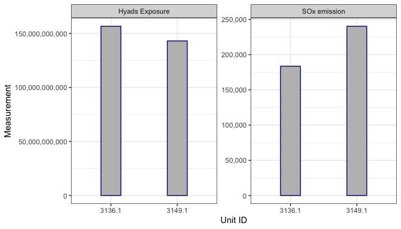

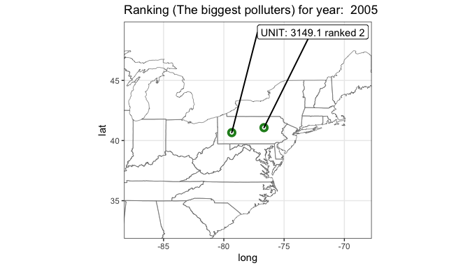

```r
plotUnitsRanked <- disperseR::plot_units_ranked(
  data.units = unitsrun,
  data.ranked = unitRanks2005,
  year = 2005,
  graph.dir = graph_dir)

plotUnitsRanked
```

Please note graphical output is authomatically saved to the `graph_dir` by the plotting functions.